# Tarea 4 - Genómica Funcional 2025

Construye dos redes. Para ambas cada una compara su grado promedio, distribución de grados, coeficiente de clusterización y diámetro.

- Una red aleatoria tipo Erdos-Rényi.

  ```r
  set.seed(42)  # Fijamos una semilla para reproducibilidad
  red_ER <- sample_gnp(100, 0.05, directed = FALSE)

  # Grado promedio
  grado_promedio_ER <- mean(degree(red_ER))
  grado_promedio_ER
  ```

  ```
  ## [1] 4.66
  ```

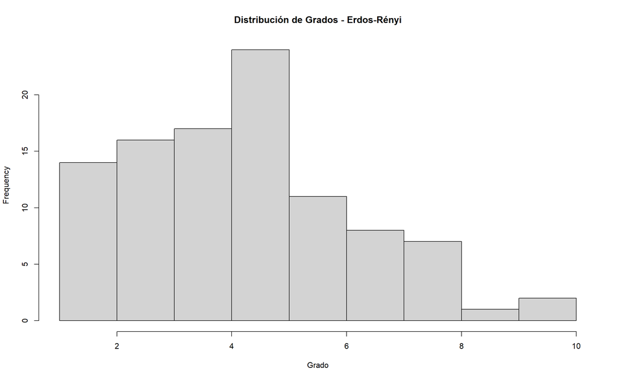

  ```r
  # Distribución de grados
  hist(degree(red_ER), main = "Distribución de Grados - Erdos-Rényi", xlab = "Grado")
  ```

  ```r
  # Coeficiente de clusterización
  coef_cluster_ER <- transitivity(red_ER, type = "global")
  coef_cluster_ER
  ```

  ```
  ## [1] 0.056926
  ```

  ```r
  # Diámetro
  diametro_ER <- diameter(red_ER)
  diametro_ER
  ```

  ```
  ## [1] 7
  ```

- Una red tipo “scale-free” usando el modelo Barabási–Albert.

  ```r
  red_BA <- sample_pa(100, m = 3, directed = FALSE)

  # Grado promedio
  grado_promedio_BA <- mean(degree(red_BA))
  grado_promedio_BA
  ```

  ```
  ## [1] 5.88
  ```

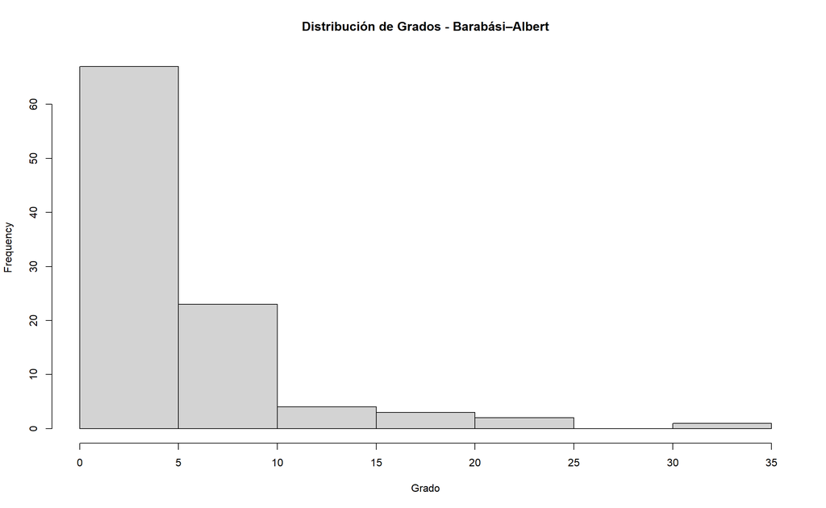

  ```r
  # Distribución de grados
  hist(degree(red_BA), main = "Distribución de Grados - Barabási–Albert", xlab = "Grado")
  ```

  ```r
  # Coeficiente de clusterización
  coef_cluster_BA <- transitivity(red_BA, type = "global")
  coef_cluster_BA
  ```

  ```
  ## [1] 0.08760764
  ```

  ```r
  # Diámetro
  diametro_BA <- diameter(red_BA)
  diametro_BA
  ```

  ```
  ## [1] 4
  ```

- Interpreta las diferencias en el contexto de redes biológicas.

```
##                       Propiedad Red.Erdos.Rényi Red.Barabási.Albert
## 1                Grado Promedio        4.660000          5.88000000
## 2 Coeficiente de Clusterización        0.056926          0.08760764
## 3                      Diámetro        7.000000          4.00000000
```

Después de ver los resultados, se notan diferencias que cuadran bastante con lo que se ve en redes biológicas reales, por ejemplo:

En el grado promedio en la red Barabási–Albert fue más alto que en la Erdos-Rényi. Eso pasa porque el modelo Barabási crea nodos que tienen muchas conexiones, conocidos como “hubs”. Y eso lo vemos como cuando hay proteínas súper conectadas que interactúan con muchas otras, parecidad a un cento de calidad.

El coeficiente de clusterización también fue más alto en la red BA. No fue una diferencia enorme, pero sí se nota. Esto significa que hay más grupos donde los nodos están conectados entre sí, como si fueran mini comunidades, mejor conocidos como clusters. En redes de genes, eso se puede ver cuando ciertos genes trabajan juntos para una función específica.

En el diámetro fue bien claro: 4 en la red BA y 7 en la red ER. Recordemos que esta cifra nos quiere decir que cualquier nodo puede llegar a otro con menos pasos, siendo la en la red BA mas factible. Es como si todo estuviera más accesible

En resumen, la red Barabási–Albert se parece más a cómo funcionan las redes reales en el area biologica. Ya que aqui si se tiene hubs, módulos, y distancias más cortas entre los nodos. La Erdos-Rényi es más aleatoria y simetrica, pero no captura tan bien todo lo que conllevan los sistemas biológicos.